# LibriSpeech dataset EDA

```python
import sys
from pathlib import Path
sys.path.append(str(Path().resolve().parent))
from src.configs import DATA_PATH, CHAPTERS_TXT, SPEAKERS_TXT
import pandas as pd
import numpy as np
import matplotlib.pyplot as plt
import seaborn as sns
import soundfile as sf
from collections import Counter
from itertools import islice
from IPython.display import Audio
```

### TXT EDA

**Read TXT files**

```python
# txt files

ch_raw_cols = ["ID", "READER", "MINUTES", "SUBSET", "PROJ.", "BOOK ID", "CH. TITLE", "PROJECT TITLE"]
sp_raw_cols = ["ID", "SEX", "SUBSET", "MINUTES", "NAME"]

chapters = pd.read_csv(
    CHAPTERS_TXT,
    sep=r"\s*\|\s*",
    header=None,
    skiprows=14,
    names = ch_raw_cols,
    engine="python"
)

records = []
with open(SPEAKERS_TXT, encoding="utf-8") as f:
    for _ in range(12):
        next(f)
    for line in f:
        line = line.rstrip("\n")
        if not line or line.startswith(";"):
            continue
        # split on |, but do at most 4 splits → 5 columns
        parts = [p.strip() for p in line.split("|", 4)]
        records.append(parts)

speakers = pd.DataFrame(
    records,
    columns=["ID", "SEX", "SUBSET", "MINUTES", "NAME"]
)


dev_clean_meta_ch = chapters[chapters["SUBSET"] == "dev-clean"].drop(columns=["SUBSET"]).copy()
dev_clean_meta_sp = speakers[speakers["SUBSET"] == "dev-clean"].drop(columns=["SUBSET"]).copy()
```

```python
dev_clean_meta_ch.head()
```

|  | ID | READER | MINUTES | PROJ. | BOOK ID | CH. TITLE | PROJECT TITLE |
| --- | --- | --- | --- | --- | --- | --- | --- |
| 230 | 4943 | 3752 | 2.59 | 2528 | 3424 | Book 03 Port Arthur. 1838. Chapter 13 The Co... | For the Term of His Natural Life |
| 231 | 4944 | 3752 | 5.47 | 2528 | 3424 | Book 03 Port Arthur. 1838. Chapter 14 Mr Nor... | For the Term of His Natural Life |
| 371 | 8226 | 3536 | 3.59 | 2935 | 5140 | Mr Bozzle at Home | He Knew He Was Right |
| 407 | 9006 | 2902 | 5.37 | 3044 | 6308 | Preface (3648 words) | Hypatia |
| 408 | 9008 | 2902 | 2.72 | 3044 | 6308 | Ch 02: The Dying World, pt 1 (3605 words) | Hypatia |

```python
dev_clean_meta_sp.head()
```

|  | ID | SEX | MINUTES | NAME |
| --- | --- | --- | --- | --- |
| 46 | 84 | F | 8.02 | Christie Nowak |
| 93 | 174 | M | 8.04 | Peter Eastman |
| 135 | 251 | M | 8.04 | Mark Nelson |
| 200 | 422 | M | 8.38 | President Lethe |
| 279 | 652 | M | 8.31 | Scott Walter |

**Chapter**

```python
# Basic info
print(dev_clean_meta_ch.info(), "\n")
print("Distinct readers:", dev_clean_meta_ch['READER'].nunique())
print("Distinct books:", dev_clean_meta_ch['BOOK ID'].nunique())
```

```
<class 'pandas.core.frame.DataFrame'>
Index: 97 entries, 230 to 5823
Data columns (total 7 columns):
 #   Column         Non-Null Count  Dtype
---  ------         --------------  -----
 0   ID             97 non-null     int64
 1   READER         97 non-null     int64
 2   MINUTES        97 non-null     float64
 3   PROJ.          97 non-null     int64
 4   BOOK ID        97 non-null     int64
 5   CH. TITLE      97 non-null     object
 6   PROJECT TITLE  97 non-null     object
dtypes: float64(1), int64(4), object(2)
memory usage: 6.1+ KB
None

Distinct readers: 40
Distinct books: 63
```

```python
# Duration summary
print(dev_clean_meta_ch['MINUTES'].describe())
```

```
count    97.000000
mean      3.332680
std       1.831023
min       0.700000
25%       2.360000
50%       2.850000
75%       3.400000
max       8.380000
Name: MINUTES, dtype: float64
```

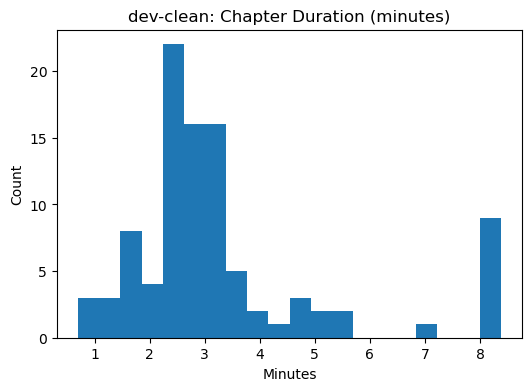

```python
# Histogram of chapter durations
plt.figure(figsize=(6,4))
plt.hist(dev_clean_meta_ch['MINUTES'], bins=20)
plt.title('dev-clean: Chapter Duration (minutes)')
plt.xlabel('Minutes')
plt.ylabel('Count')
plt.show()
```

**Speaker**

```python
# Basic info
print(dev_clean_meta_sp.info(), "\n")
print("Distinct readers:", dev_clean_meta_sp['ID'].nunique()) # Matches chapters info
```

```
<class 'pandas.core.frame.DataFrame'>
Index: 40 entries, 46 to 2470
Data columns (total 4 columns):
 #   Column   Non-Null Count  Dtype
---  ------   --------------  -----
 0   ID       40 non-null     object
 1   SEX      40 non-null     object
 2   MINUTES  40 non-null     object
 3   NAME     40 non-null     object
dtypes: object(4)
memory usage: 1.6+ KB
None

Distinct readers: 40
```

```python
# Quick summary of speaker durations
dev_clean_meta_sp["MINUTES"] = dev_clean_meta_sp["MINUTES"].astype(float)

print(dev_clean_meta_sp["MINUTES"].describe())
```

```
count    40.000000
mean      8.082000
std       0.080518
min       8.000000
25%       8.030000
50%       8.060000
75%       8.110000
max       8.380000
Name: MINUTES, dtype: float64
```

```python
# Gender breakdown
print(dev_clean_meta_sp['SEX'].value_counts())
```

```
SEX
F    20
M    20
Name: count, dtype: int64
```

```python
# Check consistency
sp = dev_clean_meta_sp.copy()
sp['spk_min'] = sp['MINUTES'].astype(float)
sp['ID'] = sp['ID'].astype(int)

chap_sum = (
    dev_clean_meta_ch
    .groupby('READER')['MINUTES']
    .sum()
    .reset_index(name='chap_sum_min')
)

comparison = (
    sp[["ID","spk_min"]]
      .rename(columns={"ID":"reader_id"})
      .merge(
         chap_sum.rename(columns={"READER":"reader_id"}),
         on="reader_id",
         how="inner"
      )
)

comparison["diff_min"] = comparison["spk_min"] - comparison["chap_sum_min"]

print("Check if the read minutes for reader are same in both dataframe:")
print(f"Number of different read minutes: {len(comparison[comparison["diff_min"] > 0.01])}")
```

```
Check if the read minutes for reader are same in both dataframe:
Number of different read minutes: 0
```

### Audio EDA

**Gather location for all file and its transcript**

```python
items = []
for sp_dir in DATA_PATH.iterdir():
    if not sp_dir.is_dir():
        continue
    for ch_dir in sp_dir.iterdir():
        if not ch_dir.is_dir():
            continue
        trans = ch_dir / f"{sp_dir.name}-{ch_dir.name}.trans.txt"
        if not trans.exists():
            continue
        for flac in ch_dir.glob("*.flac"):
            items.append({
                "speaker": sp_dir.name,
                "chapter": ch_dir.name,
                "flac": flac,
                "trans": trans
            })

print(f"Found {len(items)} utterances across {len({i['speaker'] for i in items})} speakers.")
```

```
Found 2703 utterances across 40 speakers.
```

**Read transcripts into a lookup dict**

```python
trans_cache = {}

for entry in items:
    tp = entry["trans"]
    if tp not in trans_cache:
        d = {}
        with open(tp, encoding="utf-8") as f:
            for line in f:
                line = line.strip()
                if not line or line.startswith(";"):
                    continue
                # split at first space only
                utt_id, text = line.split(" ", 1)
                d[utt_id] = text
        trans_cache[tp] = d

# Spot-check
some_tp = next(iter(trans_cache))
print(f"Loaded {len(trans_cache[some_tp])} utterances from {some_tp.name}")
for utt, txt in list(trans_cache[some_tp].items())[:5]:
    print(utt, ":", txt)
```

```
Loaded 15 utterances from 1272-128104.trans.txt
1272-128104-0000 : MISTER QUILTER IS THE APOSTLE OF THE MIDDLE CLASSES AND WE ARE GLAD TO WELCOME HIS GOSPEL
1272-128104-0001 : NOR IS MISTER QUILTER'S MANNER LESS INTERESTING THAN HIS MATTER
1272-128104-0002 : HE TELLS US THAT AT THIS FESTIVE SEASON OF THE YEAR WITH CHRISTMAS AND ROAST BEEF LOOMING BEFORE US SIMILES DRAWN FROM EATING AND ITS RESULTS OCCUR MOST READILY TO THE MIND
1272-128104-0003 : HE HAS GRAVE DOUBTS WHETHER SIR FREDERICK LEIGHTON'S WORK IS REALLY GREEK AFTER ALL AND CAN DISCOVER IN IT BUT LITTLE OF ROCKY ITHACA
1272-128104-0004 : LINNELL'S PICTURES ARE A SORT OF UP GUARDS AND AT EM PAINTINGS AND MASON'S EXQUISITE IDYLLS ARE AS NATIONAL AS A JINGO POEM MISTER BIRKET FOSTER'S LANDSCAPES SMILE AT ONE MUCH IN THE SAME WAY THAT MISTER CARKER USED TO FLASH HIS TEETH AND MISTER JOHN COLLIER GIVES HIS SITTER A CHE…
```

**Build DataFrame**

```python
records = []

for entry in items:
    utt_id = entry["flac"].stem

    # measure the audio duration in seconds
    dur_s = sf.info(entry["flac"]).duration

    # transcript text
    txt = trans_cache[entry["trans"]].get(utt_id, "")

    # count words
    n_words = len(txt.split())

    # record the row
    records.append({
        "speaker_id": entry["speaker"],
        "chapter_id": entry["chapter"],
        "utt_id":     utt_id,
        "duration_s": dur_s,
        "n_words":    n_words,
        "text":       txt
    })

# Build the DataFrame
utt_df = pd.DataFrame(records)

print("Total utterances:", len(utt_df))
display(utt_df.head())
```

```
Total utterances: 2703
```

|  | speaker_id | chapter_id | utt_id | duration_s | n_words | text |
| --- | --- | --- | --- | --- | --- | --- |
| 0 | 1272 | 128104 | 1272-128104-0000 | 5.855 | 17 | MISTER QUILTER IS THE APOSTLE OF THE MIDDLE CL... |
| 1 | 1272 | 128104 | 1272-128104-0001 | 4.815 | 10 | NOR IS MISTER QUILTER'S MANNER LESS INTERESTIN... |
| 2 | 1272 | 128104 | 1272-128104-0002 | 12.485 | 32 | HE TELLS US THAT AT THIS FESTIVE SEASON OF THE... |
| 3 | 1272 | 128104 | 1272-128104-0003 | 9.900 | 24 | HE HAS GRAVE DOUBTS WHETHER SIR FREDERICK LEIG... |
| 4 | 1272 | 128104 | 1272-128104-0004 | 29.400 | 68 | LINNELL'S PICTURES ARE A SORT OF UP GUARDS AND... |

```python
# Summary statistics
stats = utt_df[['duration_s', 'n_words']].describe()
print("Summary statistics for utterance durations and word counts:\n", stats)
```

```
Summary statistics for utterance durations and word counts:
         duration_s      n_words
count  2703.000000  2703.000000
mean      7.175775    20.126526
std       4.695612    13.524448
min       1.445000     1.000000
25%       3.760000    10.000000
50%       5.920000    17.000000
75%       9.267500    26.000000
max      32.645000    92.000000
```

From these 2,703 utterances in `dev-clean`, we see:

- Duration
  - The average snippet is about 7.2 seconds long (σ ≈ 4.7 s).
  - Half of all utterances fall between roughly 3.8 s (25th pct) and 9.3 s (75th pct), with a median of 5.9 s.
  - The shortest clip is about 1.45 s, and the longest is around 32.6 s, so there are a few much longer passages.
- Word count
  - On average each utterance contains about 20 words (σ ≈ 13.5).
  - The middle 50% spans from 10 words (25th pct) to 26 words (75th pct), with a median of 17 words.
  - We see utterances as short as a single word and as long as 92 words in the extreme tail.

Interpretation: most utterances are brief (around 6 s and 17 words), which is typical for clean read speech. The right‐hand tails (long clips >20 s or >50 words) represent outliers you may want to inspect or handle specially when building your ASR pipelines.

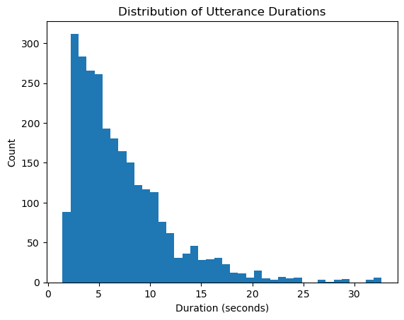

```python
# Histogram of utterance durations
plt.hist(utt_df['duration_s'], bins=40)
plt.xlabel('Duration (seconds)')
plt.ylabel('Count')
plt.title('Distribution of Utterance Durations')
plt.show()
```

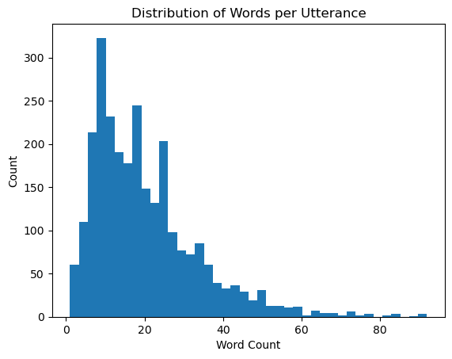

```python
# Histogram of words per utterance
plt.hist(utt_df['n_words'], bins=40)
plt.xlabel('Word Count')
plt.ylabel('Count')
plt.title('Distribution of Words per Utterance')
plt.show()
```

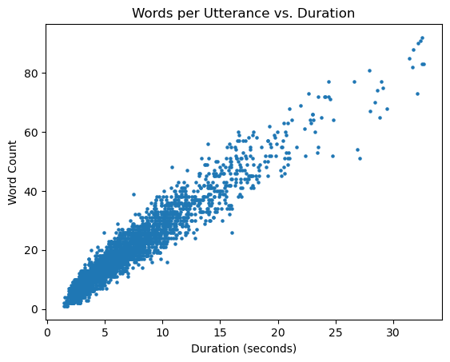

```python
# Scatter plot: words vs. duration
plt.scatter(utt_df['duration_s'], utt_df['n_words'], s=5)
plt.xlabel('Duration (seconds)')
plt.ylabel('Word Count')
plt.title('Words per Utterance vs. Duration')
plt.show()
```

There’s a strong positive linear relationship between utterance duration and word count—longer audio clips nearly always contain more words.

```python
# build a single big list of all words
all_tokens = [t for text in utt_df['text'] for t in text.split()]
counter = Counter(all_tokens)

print("Total tokens:", len(all_tokens))
print("Unique types:", len(counter))

# top 20 most common words
print("Top 20 uni-gram:", counter.most_common(20))

# bigrams
bigrams = Counter(zip(all_tokens, islice(all_tokens, 1, None)))
print("Top 20 bigrams:", bigrams.most_common(20))
```

```
Total tokens: 54402
Unique types: 8333
Top 20 uni-gram: [('THE', 3448), ('AND', 1915), ('OF', 1737), ('TO', 1378), ('A', 1198), ('IN', 940), ('WAS', 684), ('HE', 679), ('THAT', 642), ('I', 628), ('IT', 627), ('HIS', 590), ('WITH', 470), ('HAD', 443), ('AS', 421), ('FOR', 401), ('IS', 369), ('YOU', 343), ('NOT', 341), ('BUT', 340)]
Top 20 bigrams: [(('OF', 'THE'), 423), (('IN', 'THE'), 264), (('TO', 'THE'), 176), (('ON', 'THE'), 125), (('AND', 'THE'), 124), (('IT', 'WAS'), 110), (('IN', 'A'), 92), (('OF', 'A'), 87), (('AT', 'THE'), 85), (('OF', 'HIS'), 84), (('IT', 'IS'), 76), (('WITH', 'THE'), 75), (('TO', 'BE'), 74), (('HE',…
```

```
        char_count  token_count
count  2703.000000  2703.000000
mean    106.716981    20.126526
std      73.947954    13.524448
min       3.000000     1.000000
25%      52.000000    10.000000
50%      89.000000    17.000000
75%     139.000000    26.000000
max     516.000000    92.000000
```

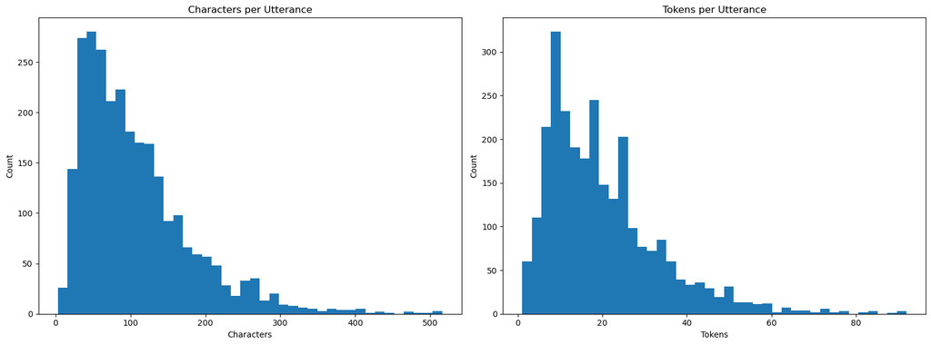

```python
# Character- and token-length distributions
utt_df['char_count'] = utt_df['text'].str.len()
utt_df['token_count'] = utt_df['text'].str.split().str.len()

# summary statistics
print(utt_df[['char_count','token_count']].describe())

# histograms
fig, axes = plt.subplots(1, 2, figsize=(16, 6))

# Top: characters per utterance
axes[0].hist(utt_df['char_count'], bins=40)
axes[0].set_title('Characters per Utterance')
axes[0].set_xlabel('Characters')
axes[0].set_ylabel('Count')

# Bottom: tokens per utterance
axes[1].hist(utt_df['token_count'], bins=40)
axes[1].set_title('Tokens per Utterance')
axes[1].set_xlabel('Tokens')
axes[1].set_ylabel('Count')

plt.tight_layout()
plt.show()
```

```
count    2703.000000
mean        2.772875
std         0.615193
min         0.563380
25%         2.410607
50%         2.784048
75%         3.160271
max         5.257836
Name: wps, dtype: float64
```

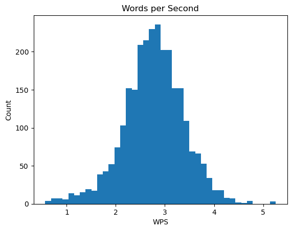

```python
# Speaking rate (words/sec)

utt_df['wps'] = utt_df['n_words'] / utt_df['duration_s']
print(utt_df['wps'].describe())

plt.hist(utt_df['wps'], bins=40)
plt.title('Words per Second')
plt.xlabel('WPS')
plt.ylabel('Count')
plt.show()
```

```
       utt_count    avg_dur  avg_words    avg_wps
count   40.00000  40.000000  40.000000  40.000000
mean    67.57500   7.672470  21.390763   2.758087
std     16.71463   2.161736   5.846463   0.318879
min     36.00000   4.788218  12.877778   2.006730
25%     56.50000   6.239359  16.980014   2.526199
50%     68.00000   7.213331  19.804193   2.795331
75%     78.00000   8.656180  25.503236   3.002246
max    101.00000  13.972778  35.722222   3.348769
```

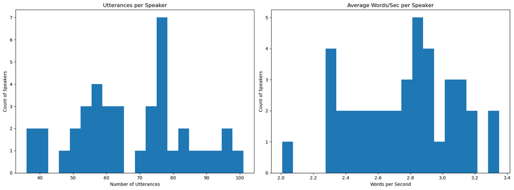

```python
spk_stats = (
    utt_df
    .groupby('speaker_id')
    .agg(
      utt_count=('utt_id','size'),
      avg_dur=('duration_s','mean'),
      avg_words=('n_words','mean'),
      avg_wps=('wps','mean'),
    )
    .reset_index()
)
print(spk_stats.describe())

fig, axes = plt.subplots(1, 2, figsize=(16, 6))

# Histogram of utterances per speaker
axes[0].hist(spk_stats['utt_count'], bins=20)
axes[0].set_title('Utterances per Speaker')
axes[0].set_xlabel('Number of Utterances')
axes[0].set_ylabel('Count of Speakers')

# Histogram of average words/sec per speaker
axes[1].hist(spk_stats['avg_wps'], bins=20)
axes[1].set_title('Average Words/Sec per Speaker')
axes[1].set_xlabel('Words per Second')
axes[1].set_ylabel('Count of Speakers')

plt.tight_layout()
plt.show()
```

### Example audio

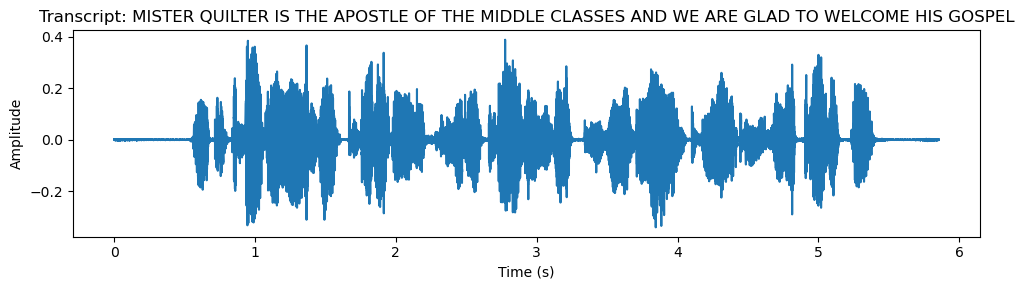

```python
example = items[0]
flac_path = example["flac"]
utt_id = flac_path.stem

# Load audio
audio, sr = sf.read(flac_path)

# Retrieve transcript
transcript = trans_cache[example["trans"]].get(utt_id, "")

# Plot waveform with transcript as title
times = np.linspace(0, len(audio) / sr, num=len(audio))

plt.figure(figsize=(10, 3))
plt.plot(times, audio)
plt.title(f"Transcript: {transcript}")
plt.xlabel("Time (s)")
plt.ylabel("Amplitude")
plt.tight_layout()
plt.show()
```

```python
Audio(audio, rate=sr)
```

[interactive chart not shown]